# Practical Machine Learning week1

## Plotting predictors (10:39)

### notes:

Don’t use the test set for exploration!  
###Thins you should be looking for:  
Imblance in outcomes/predictors  
Outliers: may need to add variable  
Groups of points not explained by a predictor  
Skewed variables: transform needed

```r
library(ISLR);library(ggplot2);library(caret)
data(Wage)
summary(Wage)
```

```
##       year           age              sex                    maritl
##  Min.   :2003   Min.   :18.0   1. Male  :3000   1. Never Married: 648
##  1st Qu.:2004   1st Qu.:33.8   2. Female:   0   2. Married      :2074
##  Median :2006   Median :42.0                    3. Widowed      :  19
##  Mean   :2006   Mean   :42.4                    4. Divorced     : 204
##  3rd Qu.:2008   3rd Qu.:51.0                    5. Separated    :  55
##  Max.   :2009   Max.   :80.0
##
##        race                   education                     region
##  1. White:2480   1. < HS Grad      :268   2. Middle Atlantic   :3000
##  2. Black: 293   2. HS Grad        :971   1. New England       :   0
##  3. Asian: 190   3. Some College   :650   3. East North Central:   0
##  4. Other:  37   4. College Grad   :685   4. West North Central:   0
##                  5. Advanced Degree:426   5. South Atlantic    :   0
##                                           6. East South Central:   0
##                                           (Other)              :   0
##            jobclass               health      health_ins      logwage
##  1. Industrial :1544   1. <=Good     : 858   1. Yes:2083   Min.   :3.00
##  2. Information:1456   2. >=Very Good:2142   2. No : 917   1st Qu.:4.45
##                                                            Median :4.65
##                                                            Mean   :4.65
##                                                            3rd Qu.:4.86
##                                                            Max.   :5.76
##
##       wage
##  Min.   : 20.1
##  1st Qu.: 85.4
##  Median :104.9
##  Mean   :111.7
##  3rd Qu.:128.7
##  Max.   :318.3
##
```

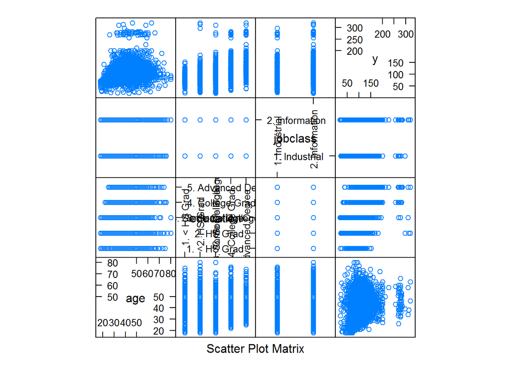

```r
inTrain <- createDataPartition( y=Wage$wage, p=0.7, list=F )
training <- Wage[inTrain, ]
testing <- Wage[-inTrain, ]
featurePlot( x=training[,c("age","education","jobclass")],
             y=training$wage, plot="pairs")
```

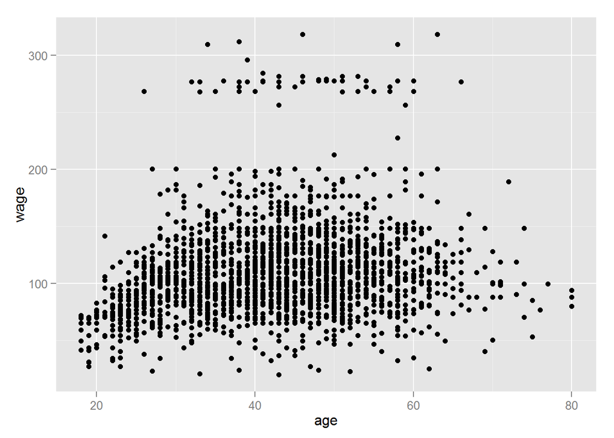

```r
# 1v1
qplot( age, wage, data = training)
```

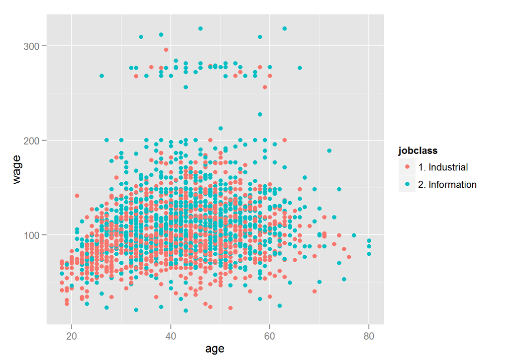

```r
# chunk?
qplot( age, wage, color=jobclass, data = training)
```

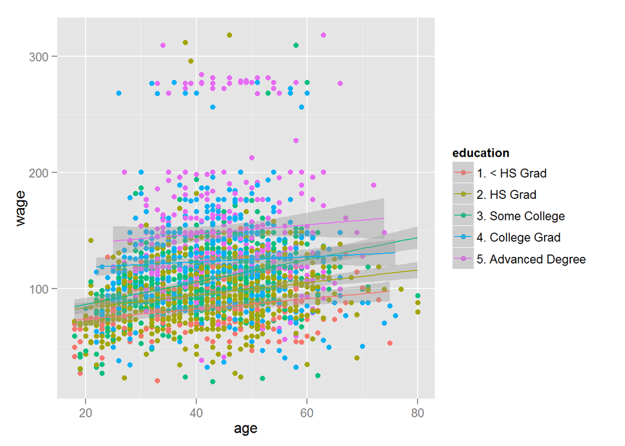

```r
# add regression smoothers, group by diff color
qq <- qplot( age, wage, color=education, data = training)
qq + geom_smooth( method='lm', formula=y~x )
```

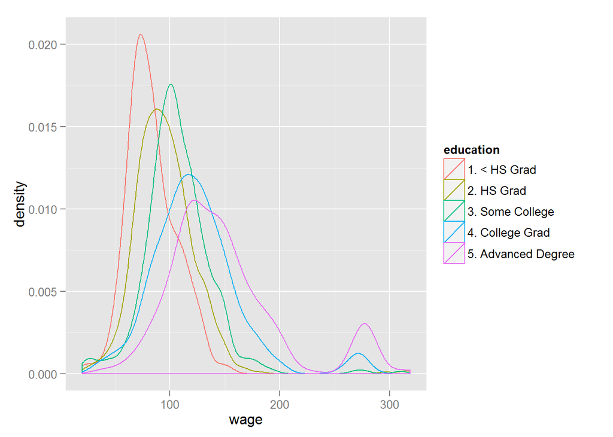

```r
# density plots
qplot(wage, color=education, data=training, geom="density")
```

## Basic preprocessing (10:52)

why? abnormal, outliers etc…

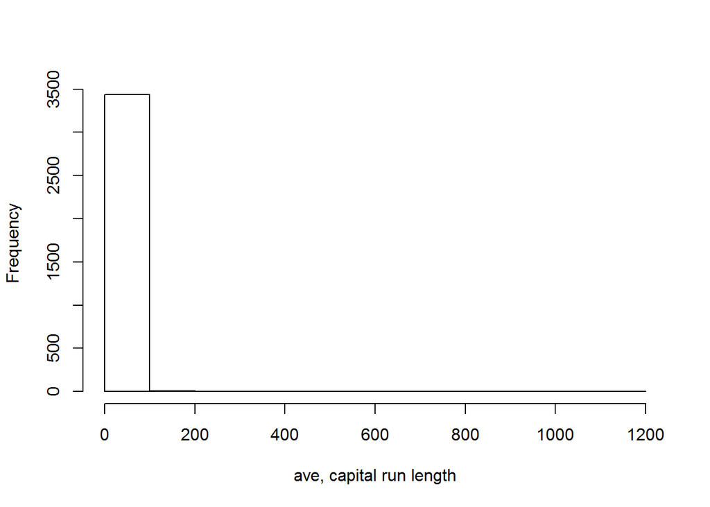

```r
rm(list=ls())
library(caret);library(kernlab);data(spam)
inTrain <- createDataPartition( y = spam$type, p=0.75, list=F)
training <- spam[inTrain, ]
testing <- spam[-inTrain, ]

hist( training$capitalAve, main="",xlab="ave, capital run length")
```

```r
mean( training$capitalAve);sd( training$capitalAve ) # sd too big
```

```
## [1] 5.338
```

```
## [1] 33.46
```

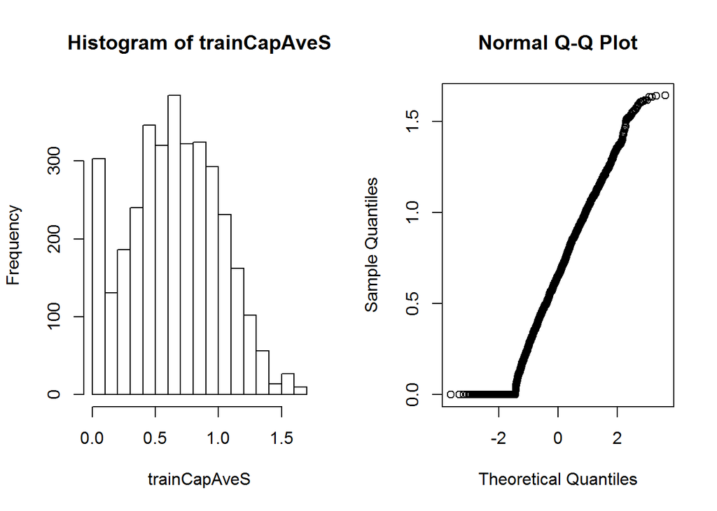

```r
# standardizing_ use train mean & sd !!!
tranCapAve <-  training$capitalAve
trainCapAveS <-  (tranCapAve - mean(tranCapAve))/sd(tranCapAve)
testCapAve <- testing$capitalAve
testCapAveS <- (testCapAve -  mean(tranCapAve))/sd(tranCapAve)

# box-cox transforms
preObj <- preProcess( training[,-58], method=c("BoxCox"))
trainCapAveS <- predict(preObj, training[,-58])$capitalAve
par(mfrow=c(1,2)); hist(trainCapAveS); qqnorm(trainCapAveS)
```

```r
par(mfrow=c(1,1))
```

## Covariate creation (17:31)

### 2 levels of covariate creation

1.from raw data to covariate: capital letters from each mail, “you” freqs…  
2.transforming tidy covariates: a^2

### level1,Raw data -> convariates

test files: frequency of words, google ngrams, freq of capital letters…  
images: edges, cornors…  
people: height, weight…  
### level2, tidy -> new more necessary for glm, svms than classification trees.  
should be done only on the training set the best approach is through exploratory analysis( plot/tables)

```r
library(ISLR);library(ggplot2);library(caret)
data(Wage)
summary(Wage)
```

```
##       year           age              sex                    maritl
##  Min.   :2003   Min.   :18.0   1. Male  :3000   1. Never Married: 648
##  1st Qu.:2004   1st Qu.:33.8   2. Female:   0   2. Married      :2074
##  Median :2006   Median :42.0                    3. Widowed      :  19
##  Mean   :2006   Mean   :42.4                    4. Divorced     : 204
##  3rd Qu.:2008   3rd Qu.:51.0                    5. Separated    :  55
##  Max.   :2009   Max.   :80.0
##
##        race                   education                     region
##  1. White:2480   1. < HS Grad      :268   2. Middle Atlantic   :3000
##  2. Black: 293   2. HS Grad        :971   1. New England       :   0
##  3. Asian: 190   3. Some College   :650   3. East North Central:   0
##  4. Other:  37   4. College Grad   :685   4. West North Central:   0
##                  5. Advanced Degree:426   5. South Atlantic    :   0
##                                           6. East South Central:   0
##                                           (Other)              :   0
##            jobclass               health      health_ins      logwage
##  1. Industrial :1544   1. <=Good     : 858   1. Yes:2083   Min.   :3.00
##  2. Information:1456   2. >=Very Good:2142   2. No : 917   1st Qu.:4.45
##                                                            Median :4.65
##                                                            Mean   :4.65
##                                                            3rd Qu.:4.86
##                                                            Max.   :5.76
##
##       wage
##  Min.   : 20.1
##  1st Qu.: 85.4
##  Median :104.9
##  Mean   :111.7
##  3rd Qu.:128.7
##  Max.   :318.3
##
```

```r
inTrain <- createDataPartition( y = Wage$wage, p=0.75, list=F)
training <- Wage[inTrain, ]
testing <- Wage[-inTrain, ]

table(training$jobclass)
```

```
##
##  1. Industrial 2. Information
##           1159           1092
```

```r
# creating dummy variables
dummies <- dummyVars( wage ~ jobclass, data= training)
head( predict(dummies, newdata= training))
```

```
##        jobclass.1. Industrial jobclass.2. Information
## 231655                      1                       0
## 86582                       0                       1
## 11443                       0                       1
## 305706                      1                       0
## 160191                      1                       0
## 11141                       0                       1
```

```r
# removin zero covariates,pass
nsv <- nearZeroVar( training, saveMetrics=T )

# spline basis
library(splines)
bsBasis <- bs(training$age, df=3 )
bsBasis
```

```
##                1         2         3
##    [1,] 0.000000 0.0000000 0.000e+00
##    [2,] 0.236850 0.0253768 9.063e-04
##    [3,] 0.362526 0.3866940 1.375e-01
##    [4,] 0.426169 0.1482327 1.719e-02
##    [5,] 0.442218 0.1953988 2.878e-02
##    [6,] 0.443087 0.2436978 4.468e-02
##    [7,] 0.426169 0.1482327 1.719e-02
##    [8,] 0.000000 0.0000000 0.000e+00
##    [9,] 0.417093 0.1331149 1.416e-02
##   [10,] 0.318229 0.0540390 3.059e-03
##   [11,] 0.340371 0.0654560 4.196e-03
##   [12,] 0.362526 0.3866940 1.375e-01
##   [13,] 0.444358 0.2275981 3.886e-02
##   [14,] 0.266544 0.0339238 1.439e-03
```

[output cut: 2247 more lines]

### notes

level1 feature creation  
- science is ky. google “feature extraction for [data type]”  
- Err on overcreation of features  
- http://www.cs.nyu.edu/~yann/talks/lecun-ranzato-icml2013.pdf  
level2 feature creation  
- exploratory analysisi on the training set for creating them  
- be careful about overfitting!

## Preprocessing with principal components analysis (14:07)

### Basic PCA idea

we should pick this combination to capture the “most information” possible  
Benefits: reduced number of predictors/ reduced noise( due to averaging )

```r
rm(list=ls())
library(caret);library(kernlab);data(spam)
inTrain <- createDataPartition( y = spam$type, p=0.75, list=F)
training <- spam[inTrain, ]
testing <- spam[-inTrain, ]

M <- abs( cor(training[,-58]))
diag(M) <- 0
which( M > 0.8, arr.ind= T )
```

```
##        row col
## num857  32  31
## num415  34  31
## telnet  31  32
## num415  34  32
## direct  40  32
## telnet  31  34
## num857  32  34
## direct  40  34
## num857  32  40
## num415  34  40
```

```r
names(spam)[c(34,32)]
```

```
## [1] "num415" "num857"
```

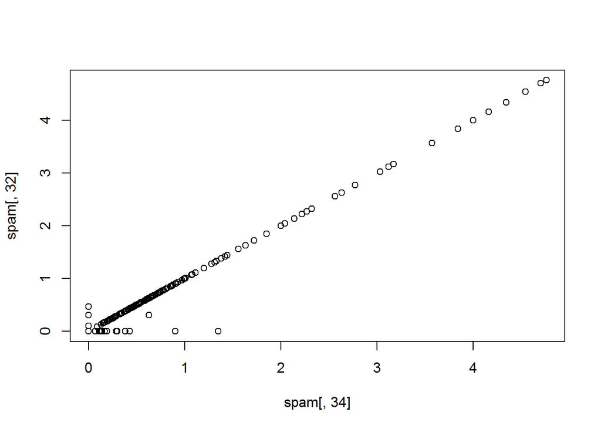

```r
plot( spam[,34] , spam[,32])
```

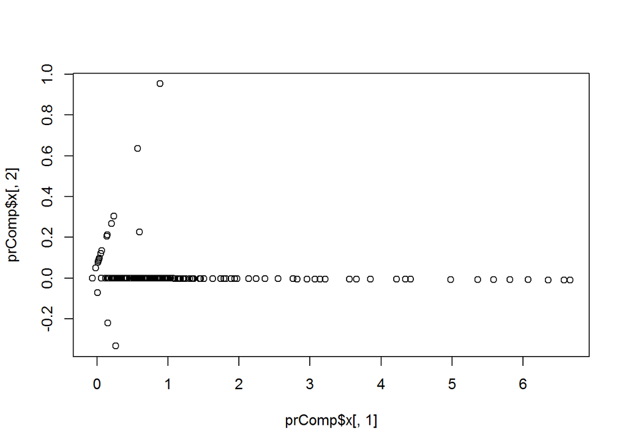

```r
### PCA/SVD

smallSpam <- spam[ , c(34,32)]
prComp <- prcomp( smallSpam)
plot( prComp$x[,1], prComp$x[,2])
```

```r
prComp$rotation
```

```
##           PC1     PC2
## num415 0.7081  0.7061
## num857 0.7061 -0.7081
```

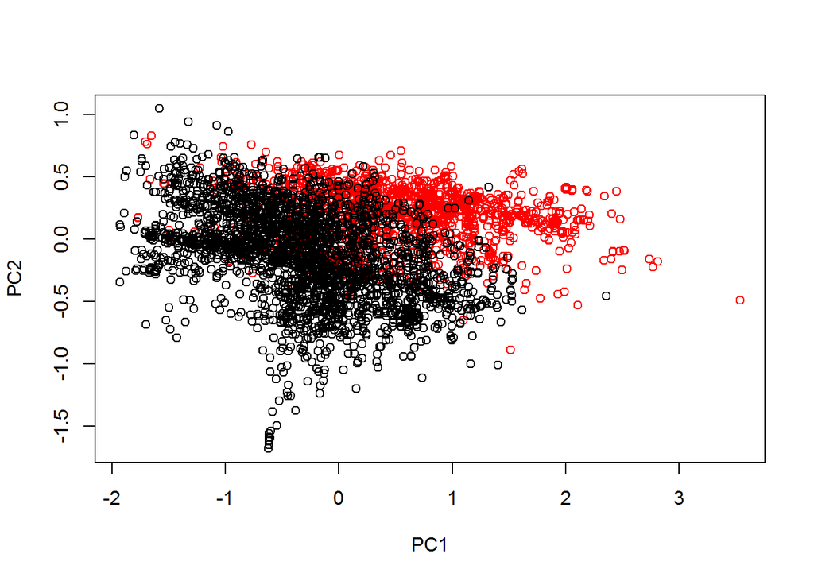

```r
# PCA ON spam data: all x into 2 comp
typeColor <- ((spam$type =="spam")*1 + 1 )
prComp <- prcomp( log10(spam[,-58]+1 )) # in case log(0) == -inf
plot( prComp$x[,1], prComp$x[,2], col=typeColor, xlab="PC1", ylab="PC2")
```

```r
# preprocessing with PCA
preProc <- preProcess( log10(training[,-58]+1), method="pca", pacComp=2 )
trainPC <- predict( preProc, log10(training[,-58]+1))
modelFit <- train( training$type ~ ., method="glm", data =  trainPC )
testPC <- predict( preProc, log10( testing[, -58]+1))
confusionMatrix( testing$type, predict( modelFit, testPC ))
```

```
## Confusion Matrix and Statistics
##
##           Reference
## Prediction nonspam spam
##    nonspam     669   28
##    spam         36  417
##
##                Accuracy : 0.944
##                  95% CI : (0.929, 0.957)
##     No Information Rate : 0.613
##     P-Value [Acc > NIR] : <2e-16
##
##                   Kappa : 0.883
##  Mcnemar's Test P-Value : 0.382
##
##             Sensitivity : 0.949
##             Specificity : 0.937
##          Pos Pred Value : 0.960
##          Neg Pred Value : 0.921
##              Prevalence : 0.613
##          Detection Rate : 0.582
##    Detection Prevalence : 0.606
##       Balanced Accuracy : 0.943
##
##        'Positive' Class : nonspam
##
```

## Predicting with Regression (12:22)

## Predicting with Regression Multiple Covariates (11:12)

factors as different level variables : see the example below, there are 10 predictors!!!

```r
rm( list=ls())
library(ISLR);library(ggplot2);library(caret)
data(Wage); Wage <- subset( Wage, select = -c(logwage))
summary(Wage)
```

```
##       year           age              sex                    maritl
##  Min.   :2003   Min.   :18.0   1. Male  :3000   1. Never Married: 648
##  1st Qu.:2004   1st Qu.:33.8   2. Female:   0   2. Married      :2074
##  Median :2006   Median :42.0                    3. Widowed      :  19
##  Mean   :2006   Mean   :42.4                    4. Divorced     : 204
##  3rd Qu.:2008   3rd Qu.:51.0                    5. Separated    :  55
##  Max.   :2009   Max.   :80.0
##
##        race                   education                     region
##  1. White:2480   1. < HS Grad      :268   2. Middle Atlantic   :3000
##  2. Black: 293   2. HS Grad        :971   1. New England       :   0
##  3. Asian: 190   3. Some College   :650   3. East North Central:   0
##  4. Other:  37   4. College Grad   :685   4. West North Central:   0
##                  5. Advanced Degree:426   5. South Atlantic    :   0
##                                           6. East South Central:   0
##                                           (Other)              :   0
##            jobclass               health      health_ins        wage
##  1. Industrial :1544   1. <=Good     : 858   1. Yes:2083   Min.   : 20.1
##  2. Information:1456   2. >=Very Good:2142   2. No : 917   1st Qu.: 85.4
##                                                            Median :104.9
##                                                            Mean   :111.7
##                                                            3rd Qu.:128.7
##                                                            Max.   :318.3
##
```

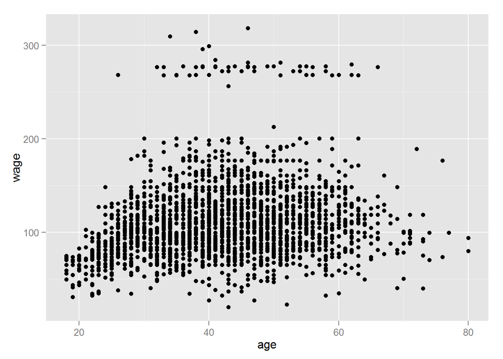

```r
inTrain <- createDataPartition( y = Wage$wage, p=0.75, list=F)
training <- Wage[inTrain, ]
testing <- Wage[-inTrain, ]

qplot( age, wage, data=training)
```

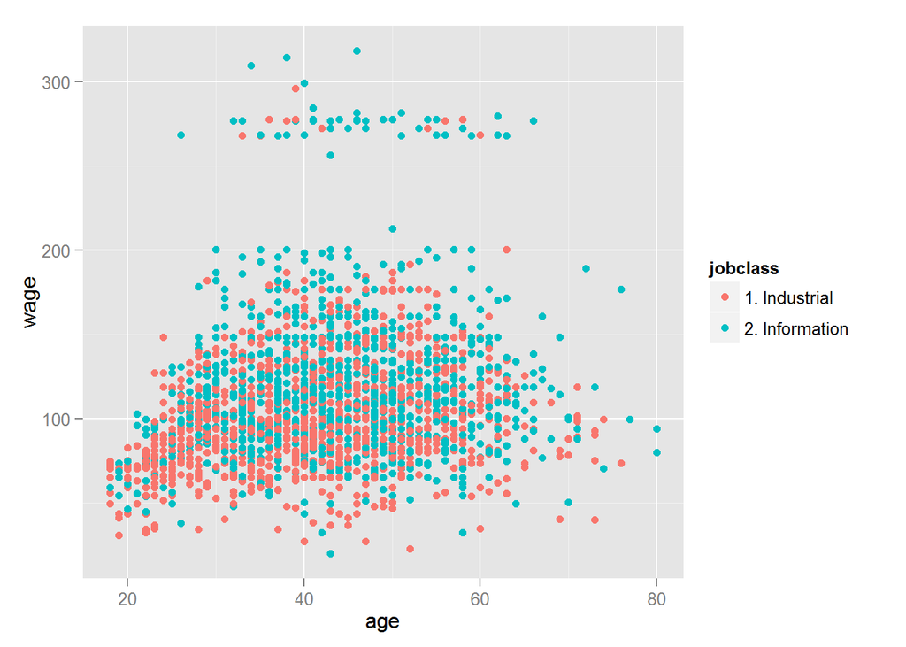

```r
qplot( age, wage, color= jobclass , data=training)
```

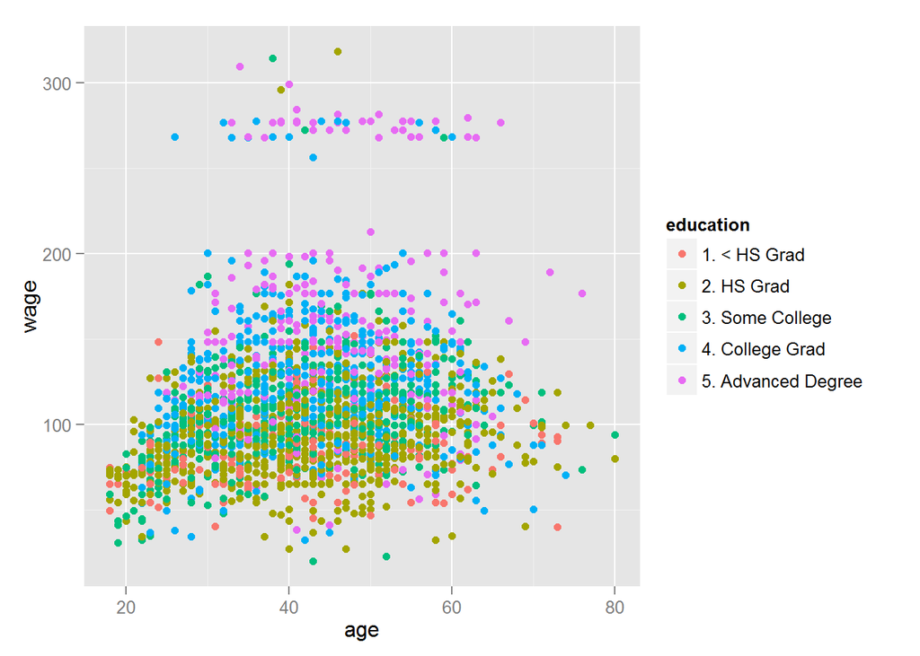

```r
qplot( age, wage, color= education , data=training)
```

```r
modFit <- train( wage~ age + jobclass + education,
                 method = "lm", data = training )
# factors as different level variables : there are 10 predictors
finMod <- modFit$finalModel
print(modFit)
```

```
## Linear Regression
##
## 2251 samples
##   10 predictor
##
## No pre-processing
## Resampling: Bootstrapped (25 reps)
##
## Summary of sample sizes: 2251, 2251, 2251, 2251, 2251, 2251, ...
##
## Resampling results
##
##   RMSE  Rsquared  RMSE SD  Rsquared SD
##   35    0.3       1        0.03
##
##
```